# Crime Rate Prediction Linear Regression

Bayu Raka Janasri

6/17/2021

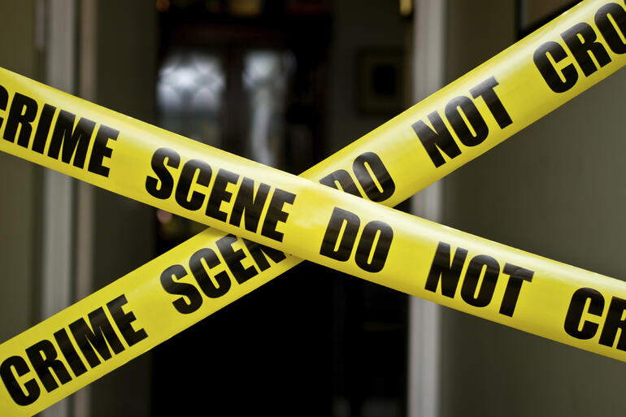

# 1 Introduction

We will make crime rate prediction using linear regression model to see what are important variabel.

# 2 Setup Library

```r
library(tidyverse)
library(caret)
library(GGally)
library(car)
library(lmtest)
```

# 3 Load dataset

```r
crime <- read.csv("crime.csv")
glimpse(crime)
```

```
## Rows: 47
## Columns: 16
## $ percent_m            <int> 151, 143, 142, 136, 141, 121, 127, 131, 157, 140,…
## $ is_south             <int> 1, 0, 1, 0, 0, 0, 1, 1, 1, 0, 0, 0, 0, 0, 1, 1, 0…
## $ mean_education       <int> 91, 113, 89, 121, 121, 110, 111, 109, 90, 118, 10…
## $ police_exp60         <int> 58, 103, 45, 149, 109, 118, 82, 115, 65, 71, 121,…
## $ police_exp59         <int> 56, 95, 44, 141, 101, 115, 79, 109, 62, 68, 116, …
## $ labour_participation <int> 510, 583, 533, 577, 591, 547, 519, 542, 553, 632,…
## $ m_per1000f           <int> 950, 1012, 969, 994, 985, 964, 982, 969, 955, 102…
## $ state_pop            <int> 33, 13, 18, 157, 18, 25, 4, 50, 39, 7, 101, 47, 2…
## $ nonwhites_per1000    <int> 301, 102, 219, 80, 30, 44, 139, 179, 286, 15, 106…
## $ unemploy_m24         <int> 108, 96, 94, 102, 91, 84, 97, 79, 81, 100, 77, 83…
## $ unemploy_m39         <int> 41, 36, 33, 39, 20, 29, 38, 35, 28, 24, 35, 31, 2…
## $ gdp                  <int> 394, 557, 318, 673, 578, 689, 620, 472, 421, 526,…
## $ inequality           <int> 261, 194, 250, 167, 174, 126, 168, 206, 239, 174,…
## $ prob_prison          <dbl> 0.084602, 0.029599, 0.083401, 0.015801, 0.041399,…
## $ time_prison          <dbl> 26.2011, 25.2999, 24.3006, 29.9012, 21.2998, 20.9…
## $ crime_rate           <int> 791, 1635, 578, 1969, 1234, 682, 963, 1555, 856, …
```

**Check missing value**

```r
colSums(is.na(crime))
```

```
##            percent_m             is_south       mean_education
##                    0                    0                    0
##         police_exp60         police_exp59 labour_participation
##                    0                    0                    0
##           m_per1000f            state_pop    nonwhites_per1000
##                    0                    0                    0
##         unemploy_m24         unemploy_m39                  gdp
##                    0                    0                    0
##           inequality          prob_prison          time_prison
##                    0                    0                    0
##           crime_rate
##                    0
```

There is no missing value at our dataset.

# 4 Explaratory Data Analysis

Exploratory data analysis is a phase where we explore the data variables, see if there are any pattern that can indicate any kind of correlation between variables.

## 4.1 Check Correlation

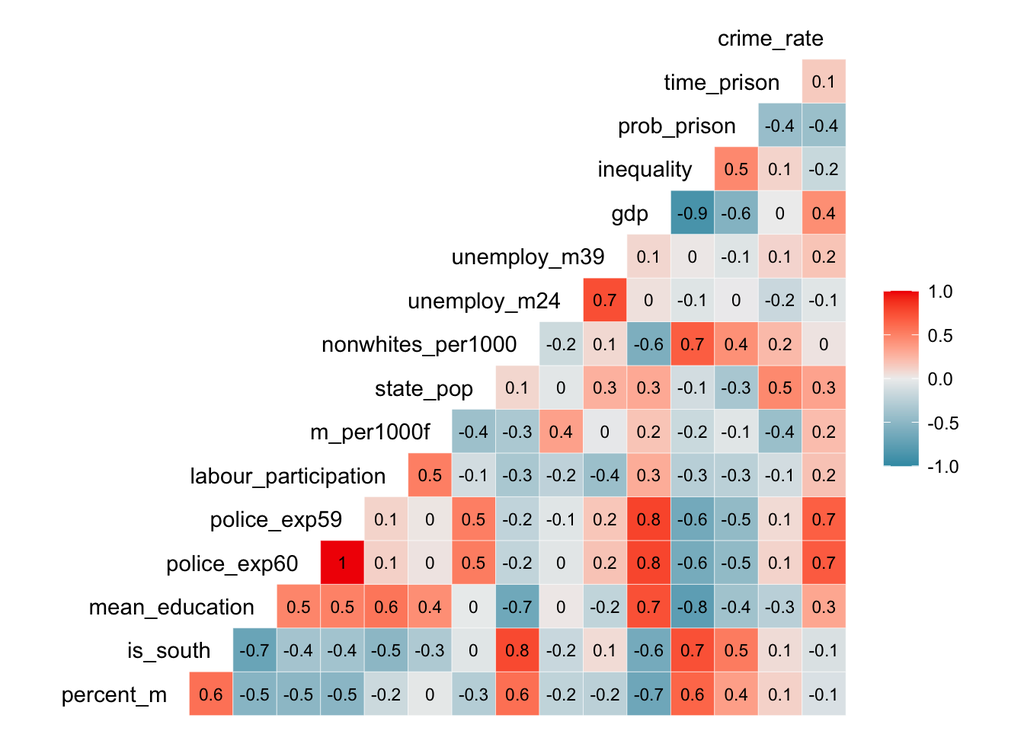

```r
ggcorr(crime, label = T, label_size = 3, hjust = 1, layout.exp = 2)
```

# 5 Modelling

## 5.1 Linear Regression

Now we will try to model the linear regression using `crime_rate` as the target variable.

```r
set.seed(100)
crime_lm <- lm(crime_rate ~. , data = crime)
summary(crime_lm)
```

```
##
## Call:
## lm(formula = crime_rate ~ ., data = crime)
##
## Residuals:
##     Min      1Q  Median      3Q     Max
## -395.74  -98.09   -6.69  112.99  512.67
##
## Coefficients:
##                        Estimate Std. Error t value Pr(>|t|)
## (Intercept)          -5984.2876  1628.3184  -3.675 0.000893 ***
## percent_m                8.7830     4.1714   2.106 0.043443 *
## is_south                -3.8035   148.7551  -0.026 0.979765
## mean_education          18.8324     6.2088   3.033 0.004861 **
## police_exp60            19.2804    10.6110   1.817 0.078892 .
## police_exp59           -10.9422    11.7478  -0.931 0.358830
## labour_participation    -0.6638     1.4697  -0.452 0.654654
## m_per1000f               1.7407     2.0354   0.855 0.398995
## state_pop               -0.7330     1.2896  -0.568 0.573845
## nonwhites_per1000        0.4204     0.6481   0.649 0.521279
## unemploy_m24            -5.8271     4.2103  -1.384 0.176238
## unemploy_m39            16.7800     8.2336   2.038 0.050161 .
## gdp                      0.9617     1.0367   0.928 0.360754
## inequality               7.0672     2.2717   3.111 0.003983 **
## prob_prison          -4855.2658  2272.3746  -2.137 0.040627 *
## time_prison             -3.4790     7.1653  -0.486 0.630708
## ---
## Signif. codes:  0 '***' 0.001 '**' 0.01 '*' 0.05 '.' 0.1 ' ' 1
##
## Residual standard error: 209.1 on 31 degrees of freedom
## Multiple R-squared:  0.8031, Adjusted R-squared:  0.7078
## F-statistic: 8.429 on 15 and 31 DF,  p-value: 3.539e-07
```

**Choose significant column**

```r
crime2 <- crime  %>%
          select(c(police_exp60, inequality, crime_rate))
```

**Create second linear regession model**

```r
set.seed(100)
crime_lm2 <- lm(crime_rate ~., data = crime2)
summary(crime_lm2)
```

```
##
## Call:
## lm(formula = crime_rate ~ ., data = crime2)
##
## Residuals:
##     Min      1Q  Median      3Q     Max
## -703.87 -121.81  -14.56  154.55  506.45
##
## Coefficients:
##              Estimate Std. Error t value Pr(>|t|)
## (Intercept)  -944.662    343.947  -2.747  0.00869 **
## police_exp60   12.415      1.637   7.582 1.62e-09 ***
## inequality      4.095      1.220   3.357  0.00163 **
## ---
## Signif. codes:  0 '***' 0.001 '**' 0.01 '*' 0.05 '.' 0.1 ' ' 1
##
## Residual standard error: 256.2 on 44 degrees of freedom
## Multiple R-squared:  0.5803, Adjusted R-squared:  0.5612
## F-statistic: 30.42 on 2 and 44 DF,  p-value: 5.061e-09
```

Our result with significant column is not quite good so far, our **R-squared is 0.5612** the value is lower than the first one.

## 5.2 Stepwise

We make another model to get good R-squared, at this time we try `stepwise` model with direction `both`.

**First stepwise model with all column**

```r
set.seed(100)
crime_step <- stats::step(crime_lm, direction = "both", trace = 0)

summary(crime_step)
```

```
##
## Call:
## lm(formula = crime_rate ~ percent_m + mean_education + police_exp60 +
##     m_per1000f + unemploy_m24 + unemploy_m39 + inequality + prob_prison,
##     data = crime)
##
## Residuals:
##     Min      1Q  Median      3Q     Max
## -444.70 -111.07    3.03  122.15  483.30
##
## Coefficients:
##                 Estimate Std. Error t value Pr(>|t|)
## (Intercept)    -6426.101   1194.611  -5.379 4.04e-06 ***
## percent_m          9.332      3.350   2.786  0.00828 **
## mean_education    18.012      5.275   3.414  0.00153 **
## police_exp60      10.265      1.552   6.613 8.26e-08 ***
## m_per1000f         2.234      1.360   1.642  0.10874
## unemploy_m24      -6.087      3.339  -1.823  0.07622 .
## unemploy_m39      18.735      7.248   2.585  0.01371 *
## inequality         6.133      1.396   4.394 8.63e-05 ***
## prob_prison    -3796.032   1490.646  -2.547  0.01505 *
## ---
## Signif. codes:  0 '***' 0.001 '**' 0.01 '*' 0.05 '.' 0.1 ' ' 1
##
## Residual standard error: 195.5 on 38 degrees of freedom
## Multiple R-squared:  0.7888, Adjusted R-squared:  0.7444
## F-statistic: 17.74 on 8 and 38 DF,  p-value: 1.159e-10
```

**Second stepwise model with significant column**

```r
set.seed(100)
crime_step2 <- stats::step(crime_lm2, direction = "both", trace = 0)

summary(crime_step2)
```

```
##
## Call:
## lm(formula = crime_rate ~ police_exp60 + inequality, data = crime2)
##
## Residuals:
##     Min      1Q  Median      3Q     Max
## -703.87 -121.81  -14.56  154.55  506.45
##
## Coefficients:
##              Estimate Std. Error t value Pr(>|t|)
## (Intercept)  -944.662    343.947  -2.747  0.00869 **
## police_exp60   12.415      1.637   7.582 1.62e-09 ***
## inequality      4.095      1.220   3.357  0.00163 **
## ---
## Signif. codes:  0 '***' 0.001 '**' 0.01 '*' 0.05 '.' 0.1 ' ' 1
##
## Residual standard error: 256.2 on 44 degrees of freedom
## Multiple R-squared:  0.5803, Adjusted R-squared:  0.5612
## F-statistic: 30.42 on 2 and 44 DF,  p-value: 5.061e-09
```

Based on our result of two models above. We can see the value of `R-squared`, our first model `R-squared` is **0.7444** and the second one is **0.5612**. The first model is better than second model eventhough the second one with significant column. We will keep first model `stepwise` as our best model.

# 6 Evaluation

## 6.1 Model Performance

We use `RMSE` to see our model performance. `RMSE` is better than `MAE` or mean absolute error, because `RMSE` squared the difference between the actual values and the predicted values, meaning that prediction with higher error will be penalized greatly. This metric is often used to compare two or more alternative models, even though it is harder to interpret than `MAE`.

**Stepwise performance**

```r
RMSE(crime_step$fitted.values, crime$crime_rate)
```

```
## [1] 175.8304
```

**Linear Regression performance**

```r
RMSE(crime_lm$fitted.values, crime$crime_rate)
```

```
## [1] 169.79
```

From RMSE calculation we get `stepwise` performance **175.8304** and `linear regression` performance **169.7918** . `linear regression` performance is better than `stepwise`.

# 7 Assumptions

After making some models, we have to check assumptions from our model. Here some assumptions :

## 7.1 Linearity

The linear regression model assumes that there is a straight-line relationship between the predictors and the response. If the true relationship is far from linear, then virtually all of the conclusions that we draw from the fit are suspect. In addition, the prediction accuracy of the model can be significantly reduced.

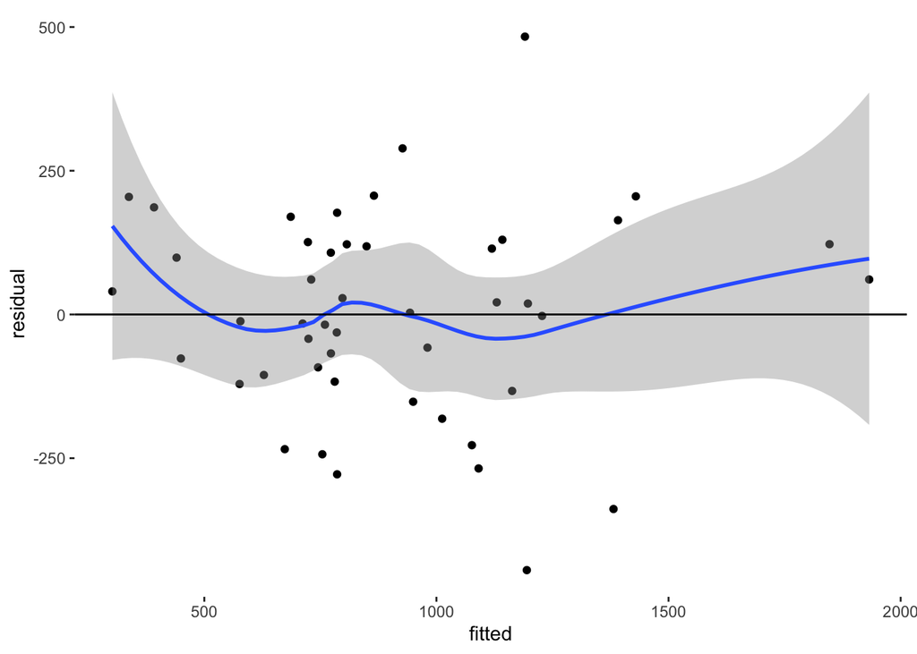

```r
data.frame(residual = crime_step$residuals, fitted = crime_step$fitted.values) %>%
  ggplot(aes(fitted, residual)) +
  geom_point() +
  geom_smooth() +
  geom_hline(aes(yintercept = 0)) +
  theme(panel.grid = element_blank(), panel.background = element_blank())
```

Based on `ggcor` and `fitted values`, it can be seen that the relationship between the target and the predictors is quite strong, even though there are some predictors that are not very strongly correlated with the target.